# Introduction to Simulation

Paul M. Magwene

October 14, 2016

# Pseudo-random numbers

When carrying out simulations, it is typical to use random number generators. Most computers can not generate true random numbers – instead we they use algorithms that approximate the generation of random numbers (pseudo-random number generators). One important difference between a true random number generator and a pseudo-random number generator is that we can regerenerate a series of pseudo-random numbers if we know the “seed” value that initialized the algorithm. We can specifically set this seed value, so that we can guarantee that two different people evaluating this notebook get the same results, even though we’re using (pseudo)random numbers in our simulation.

```r
set.seed(20161014)
```

# Generating a population to sample from

We’ll start by simulating our “population of interest” – i.e. the population we want to make inferences about. We’ll assume that our variable of interest (e.g. circulating stress hormone levels) is normally distributed with a mean of ~10 nM and a standard deviation of ~1 nM in a population of 10,000 individuals.

```r
popn <- rnorm(10000, mean = 10, sd = 1)
```

Having generated the population data, let’s assign it to a data frame and draw a histogram.

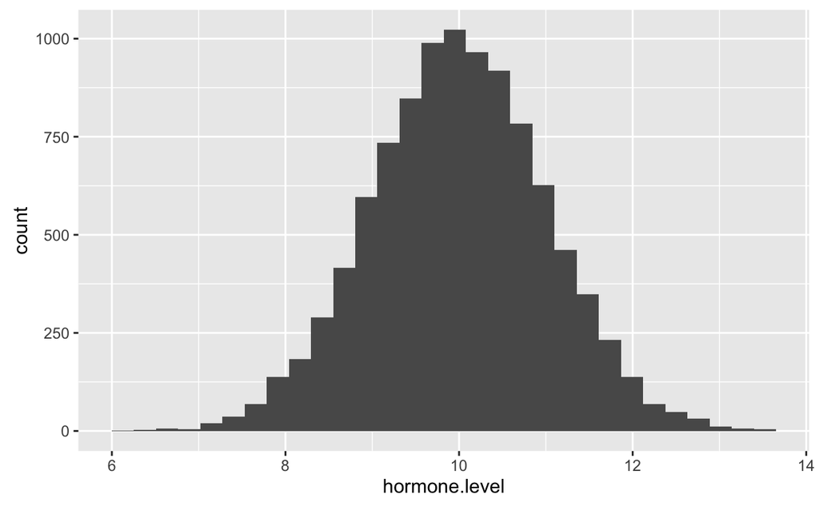

```r
library(ggplot2)
df <- data.frame(hormone.level = popn)
ggplot(df, aes(x = hormone.level)) + geom_histogram()
```

The “true” population mean is 9.9942 and the standard deviation is 1.0054.

# Taking a random sample of our population

Usually it’s impractical to measure every individual in our population of interest. Instead we take a smaller sample of individuals from the population of interest to estimate quantities of interest. The R function `sample` can be used to sample with or without replacement (`?sample`).

```r
sample1 <- sample(popn, 25)
```

The estimated mean and standard deviation of the variable of interest in this sample are:

```r
c(mean(sample1), sd(sample1))
```

```
[1] 9.980 1.037
```

# Another random sample

Let’s take a second random sample of size 25.

```r
sample2 <- sample(popn, 25)
c(mean(sample2), sd(sample2))
```

```
[1] 10.2087  0.9892
```

# Visually compare the samples

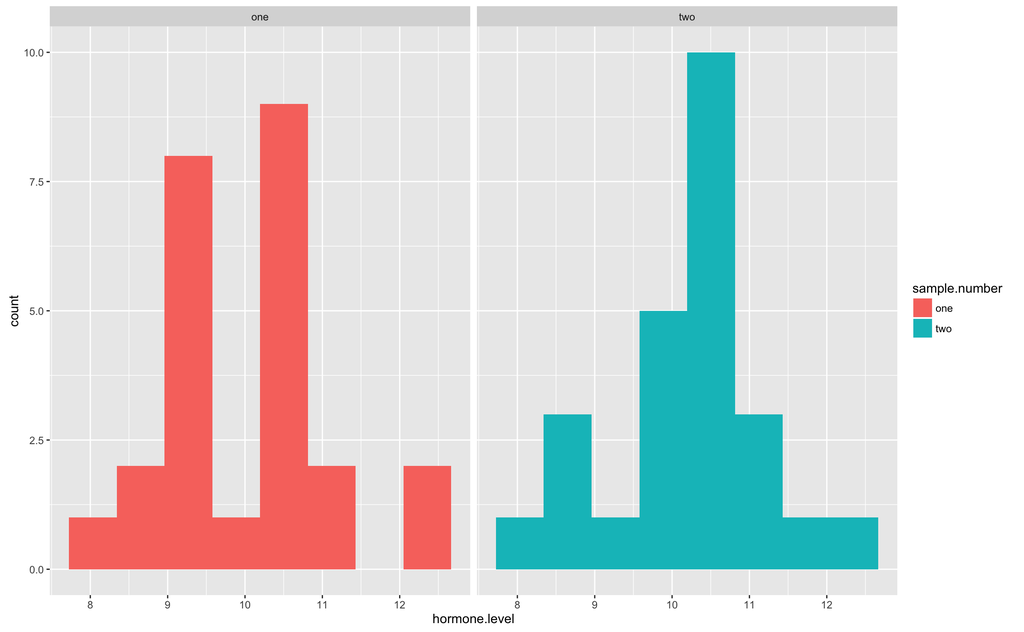

```r
df <- data.frame(hormone.level = c(sample1,sample2),
                 sample.number = c(rep("one",25), rep("two",25)))
ggplot(df,  aes(x = hormone.level, fill=sample.number)) +
  geom_histogram(bins=8) + facet_grid(.~sample.number)
```

# Generate a large number of samples of size 25

Every time we take a random sample from our population of interest we’ll get a different estimate of the mean and standard deviation (or whatever other statistics we’re interested in). To explore how well random samples of size 25 perform, generally, in terms of estimating the mean and standard deviation of the population of interest we need a large number of such samples.

It’s tedious to take one sample at a time, so we’ll generate 100 samples of size 25, and calculate the mean of each of those samples (storing the means in a vector).

```r
sample.means <- rep(NA,100)
sample.sds <- rep(NA,100)
for(i in 1:100) {
  sample.n <- sample(popn, 25)
  sample.means[i] = mean(sample.n)
  sample.sds[i] = sd(sample.n)
}
```

## Distribution of sample means

```r
sample.df <- data.frame(means = sample.means)

ggplot(sample.df, aes(x = means)) +
  geom_histogram(bins=15, alpha = 0.65) +
  geom_vline(xintercept = mean(popn), linetype="dashed", color="red", size=1)
```

[output not shown]

# How does the spread of our estimates of the mean change as sample size increases?

What happens as we increase the size of our samples? Let’s draw 100 random samples of size 50, 100, and 200 observations to compare.

First we’ll write a function to repeatedly generate samples of a given size and calculate the mean of each sample. At the end the function returns the set of estimated means.

```r
sampling.distn.of.mean <- function(X, size = 25, nreps = 100) {
  sample.means <- rep(NA, nreps)
  for(i in 1:nreps) {
    sample.n <- sample(X, size)
    sample.means[i] = mean(sample.n)
  }
  return(sample.means)
}
```

We can use this function as so:

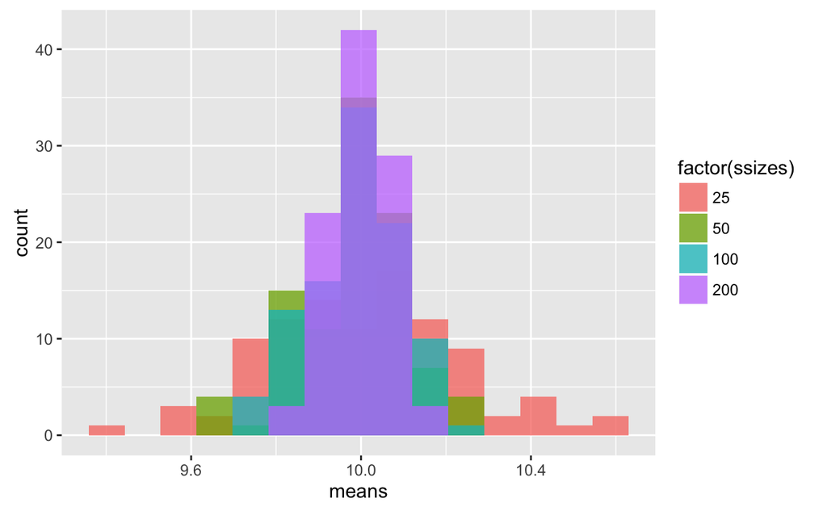

```r
means.25 <- sampling.distn.of.mean(popn, 25)
means.50 <- sampling.distn.of.mean(popn, 50)
means.100 <- sampling.distn.of.mean(popn, 100)
means.200 <- sampling.distn.of.mean(popn, 200)
df.means <- data.frame(means = c(means.25, means.50, means.100, means.200),
                       ssizes = c(rep(25, 100),
                                  rep(50, 100),
                                  rep(100, 100),
                                  rep(200, 100)))
ggplot(df.means, aes(x = means, fill = factor(ssizes))) +
  geom_histogram(bins = 15, alpha = 0.75, position = "identity")
```